# F1 History

Aditya Kaul

3/6/2018

- In order to perform analysis on the historic Formula 1 data, we first create the ERD for the data provided to us
- After creating the tables we answer different questions through SQL queries

### Entity Relationship Diagram

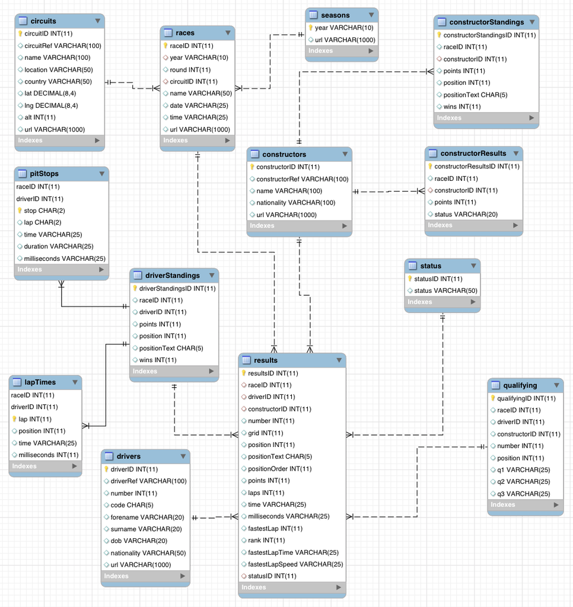

### Create Database

`CREATE DATABASE formula1;`

### Use the database created

`USE formula1;`

### Create Tables

- Create a table containing all the F1 circuits

`CREATE TABLE circuits(`  
`circuitID INT,`  
`circuitRef VARCHAR(100),`  
`name VARCHAR(100),`  
`location VARCHAR(50),`  
`country VARCHAR(50),`  
`lat DECIMAL(8,4),`  
`lng DECIMAL(8,4),`  
`alt INT,`  
`url VARCHAR(1000),`  
`PRIMARY KEY(circuitID)`  
`);`

- Load the table circuits

`LOAD DATA LOCAL INFILE '/Users/Kaul10/Desktop/f1/circuits.csv'`  
`INTO TABLE circuits`  
`FIELDS TERMINATED BY ','`  
`ENCLOSED BY '"'`  
`LINES TERMINATED BY '\n'`  
`IGNORE 1 ROWS;`

`/*DROP TABLE circuits;*/`

- Create a table containing all the constructor information

`CREATE TABLE constructors(`  
`constructorID INT,`  
`constructorRef VARCHAR(100),`  
`name VARCHAR(100),`  
`nationality VARCHAR(100),`  
`url VARCHAR(1000),`  
`PRIMARY KEY(constructorID)`  
`);`

- Load the table constructors

`LOAD DATA LOCAL INFILE '/Users/Kaul10/Desktop/f1/constructors.csv'`  
`INTO TABLE constructors`  
`FIELDS TERMINATED BY ','`  
`ENCLOSED BY '"'`  
`LINES TERMINATED BY '\n'`  
`IGNORE 1 ROWS;`

`/*DROP TABLE constructors;*/`

- Create a table containing all the constructor results

`CREATE TABLE constructorResults(`  
`constructorResultsID INT,`  
`raceID INT,`  
`constructorID INT,`  
`points INT,`  
`status VARCHAR(20),`  
`PRIMARY KEY(constructorResultsID),`  
`FOREIGN KEY(constructorID) REFERENCES constructors(constructorID)`  
`);`

- Load the table constructor results

`LOAD DATA LOCAL INFILE '/Users/Kaul10/Desktop/f1/constructorResults.csv'`  
`INTO TABLE constructorResults`  
`FIELDS TERMINATED BY ','`  
`ENCLOSED BY '"'`  
`LINES TERMINATED BY '\n'`  
`IGNORE 1 ROWS;`

`/*DROP TABLE constructorResults;*/`

- Create a table containing constructor standings

`CREATE TABLE constructorStandings(`  
`constructorStandingsID INT,`  
`raceID INT,`  
`constructorID INT,`  
`points INT,`  
`position INT,`  
`positionText CHAR(5),`  
`wins INT,`  
`PRIMARY KEY(constructorStandingsID),`  
`FOREIGN KEY(constructorID) REFERENCES constructors(constructorID)`  
`);`

- Load the table constructor standings

`LOAD DATA LOCAL INFILE '/Users/Kaul10/Desktop/f1/constructorStandings.csv'`  
`INTO TABLE constructorStandings`  
`FIELDS TERMINATED BY ','`  
`ENCLOSED BY '"'`  
`LINES TERMINATED BY '\n'`  
`IGNORE 1 ROWS;`

`/*DROP TABLE constructorStandings;*/`

- Create a table containing the driver information

`CREATE TABLE drivers(`  
`driverID INT,`  
`driverRef VARCHAR(100),`  
`number INT,`  
`code CHAR(5),`  
`forename VARCHAR(20),`  
`surname VARCHAR(20),`  
`dob VARCHAR(20),`  
`nationality VARCHAR(50),`  
`url VARCHAR(1000),`  
`PRIMARY KEY(driverID)`  
`);`

- Load the table drivers

`LOAD DATA LOCAL INFILE '/Users/Kaul10/Desktop/f1/drivers.csv'`  
`INTO TABLE drivers`  
`FIELDS TERMINATED BY ','`  
`ENCLOSED BY '"'`  
`LINES TERMINATED BY '\n'`  
`IGNORE 1 ROWS;`

`DROP TABLE drivers;`

- Create the table containing the driver standings

`CREATE TABLE driverStandings(`  
`driverStandingsID INT,`  
`raceID INT,`  
`driverID INT,`  
`points INT,`  
`position INT,`  
`positionText CHAR(5),`  
`wins INT,`  
`PRIMARY KEY(driverStandingsID),`  
`UNIQUE KEY(raceID, driverID)`  
`);`

- Load the table driver standings

`LOAD DATA LOCAL INFILE '/Users/Kaul10/Desktop/f1/driverStandings.csv'`  
`INTO TABLE driverStandings`  
`FIELDS TERMINATED BY ','`  
`ENCLOSED BY '"'`  
`LINES TERMINATED BY '\n'`  
`IGNORE 1 ROWS;`

`DROP TABLE driverStandings;`

- Do not check foreign key constraints

`SET FOREIGN_KEY_CHECKS = 0;`

- Show error status of foreign key constraint
- If the referenced columns in the parent table are not PK for that table and are just candidate keys, we should define them as unique keys else we will get error

`SHOW ENGINE INNODB STATUS;`

- Create a table containing the lap time information

`CREATE TABLE lapTimes(`  
`raceID INT,`  
`driverID INT,`  
`lap INT,`  
`position INT,`  
`time VARCHAR(25),`  
`milliseconds INT,`  
`PRIMARY KEY(raceID, driverID, lap),`  
`FOREIGN KEY(raceID, driverID) REFERENCES driverStandings(raceID, driverID)`  
`);`

- Load the table lap times

`LOAD DATA LOCAL INFILE '/Users/Kaul10/Desktop/f1/lapTimes.csv'`  
`INTO TABLE lapTimes`  
`FIELDS TERMINATED BY ','`  
`ENCLOSED BY '"'`  
`LINES TERMINATED BY '\n'`  
`IGNORE 1 ROWS;`

`/*DROP TABLE lapTimes;*/`

- Create the table containing pitstop information

`CREATE TABLE pitStops(`  
`raceID INT,`  
`driverID INT,`  
`stop CHAR(2),`  
`lap CHAR(2),`  
`time VARCHAR(25),`  
`duration VARCHAR(25),`  
`milliseconds VARCHAR(25),`  
`PRIMARY KEY(raceID, driverID, stop),`  
`FOREIGN KEY(raceID, driverID) REFERENCES driverStandings(raceID, driverID)`  
`);`

- Load the table pit stop

`LOAD DATA LOCAL INFILE '/Users/Kaul10/Desktop/f1/pitStops.csv'`  
`INTO TABLE pitStops`  
`FIELDS TERMINATED BY ','`  
`ENCLOSED BY '"'`  
`LINES TERMINATED BY '\n'`  
`IGNORE 1 ROWS;`

`/*DROP TABLE pitStops;*/`

- Create the table qualifying containing all the qualification data

`CREATE TABLE qualifying(`  
`qualifyingID INT,`  
`raceID INT,`  
`driverID INT,`  
`constructorID INT,`  
`number INT,`  
`position INT,`  
`q1 VARCHAR(25),`  
`q2 VARCHAR(25),`  
`q3 VARCHAR(25),`  
`PRIMARY KEY(qualifyingID),`  
`UNIQUE KEY(raceID, driverID,constructorID)`  
`);`

- Load table qualification

`LOAD DATA LOCAL INFILE '/Users/Kaul10/Desktop/f1/qualifying.csv'`  
`INTO TABLE qualifying`  
`FIELDS TERMINATED BY ','`  
`ENCLOSED BY '"'`  
`LINES TERMINATED BY '\n'`  
`IGNORE 1 ROWS;`

`/*DROP TABLE qualifying;*/`

- Create the table containing race information

`CREATE TABLE races(`  
`raceID INT,`  
`year VARCHAR(10),`  
`round INT,`  
`circuitID INT,`  
`name VARCHAR(50),`  
`date VARCHAR(25),`  
`time VARCHAR(25),`  
`url VARCHAR(1000),`  
`PRIMARY KEY(raceID),`  
`FOREIGN KEY(circuitID) REFERENCES circuits(circuitID),`  
`FOREIGN KEY(year) REFERENCES seasons(year)`  
`);`

- Load table races

`LOAD DATA LOCAL INFILE '/Users/Kaul10/Desktop/f1/races.csv'`  
`INTO TABLE races`  
`FIELDS TERMINATED BY ','`  
`ENCLOSED BY '"'`  
`LINES TERMINATED BY '\n'`  
`IGNORE 1 ROWS;`

`/*DROP TABLE races;*/`

- Create the table containing season information

`CREATE TABLE seasons(`  
`year VARCHAR(10),`  
`url VARCHAR(1000),`  
`PRIMARY KEY(year)`  
`);`

- Load table season

`LOAD DATA LOCAL INFILE '/Users/Kaul10/Desktop/f1/seasons.csv'`  
`INTO TABLE seasons`  
`FIELDS TERMINATED BY ','`  
`ENCLOSED BY '"'`  
`LINES TERMINATED BY '\n'`  
`IGNORE 1 ROWS;`

`/*DROP TABLE seasons;*/`

- Create the table containing status information

`CREATE TABLE status(`  
`statusID INT,`  
`status VARCHAR(50),`  
`PRIMARY KEY(statusID)`  
`);`

- Load table status

`LOAD DATA LOCAL INFILE '/Users/Kaul10/Desktop/f1/status.csv'`  
`INTO TABLE status`  
`FIELDS TERMINATED BY ','`  
`ENCLOSED BY '"'`  
`LINES TERMINATED BY '\n'`  
`IGNORE 1 ROWS;`

`/*DROP TABLE status;*/`

- Create the table containing results of all the races

`CREATE TABLE results(`  
`resultsID INT,`  
`raceID INT,`  
`driverID INT,`  
`constructorID INT,`  
`number INT,`  
`grid INT,`  
`position INT,`  
`positionText CHAR(5),`  
`positionOrder INT,`  
`points INT,`  
`laps INT,`  
`time VARCHAR(25),`  
`milliseconds VARCHAR(25),`  
`fastestLap INT,`  
`rank INT,`  
`fastestLapTime VARCHAR(25),`  
`fastestLapSpeed VARCHAR(25),`  
`statusID INT,`  
`PRIMARY KEY(resultsID),`  
`FOREIGN KEY(raceID) REFERENCES races(raceID),`  
`FOREIGN KEY(driverID) REFERENCES drivers(driverID),`  
`FOREIGN KEY(constructorID) REFERENCES constructors(constructorID),`  
`FOREIGN KEY(statusID) REFERENCES status(statusID),`  
`FOREIGN KEY(raceID, driverID, constructorID) REFERENCES qualifying(raceID, driverID, constructorID),`  
`FOREIGN KEY(raceID, driverID) REFERENCES driverStandings(raceID, driverID)`  
`);`

- Load table results

`LOAD DATA LOCAL INFILE '/Users/Kaul10/Desktop/f1/results.csv'`  
`INTO TABLE results`  
`FIELDS TERMINATED BY ','`  
`ENCLOSED BY '"'`  
`LINES TERMINATED BY '\n'`  
`IGNORE 1 ROWS;`

`/*DROP TABLE results;*/`

### SQL Queries

- Total number of first position finishes for all the drivers

`WITH top_results AS(`  
`SELECT * FROM results`  
`WHERE 1 = 1`  
`AND position = '1'`  
`)`

`SELECT d.forename, d.surname, COUNT(*) AS no_of_wins FROM top_results tr`  
`INNER JOIN drivers d`  
`ON tr.driverId = d.driverId`  
`WHERE 1 = 1`  
`GROUP BY d.forename, d.surname`  
`ORDER BY COUNT(*) DESC;`

- Total number of podium finishes for all the drivers

`WITH top_results AS(`  
`SELECT * FROM results`  
`WHERE 1 = 1`  
`AND position IN ('1','2','3')`  
`)`

`SELECT d.forename, d.surname, COUNT(*) AS podium_finishes FROM top_results tr`  
`INNER JOIN drivers d`  
`ON tr.driverId = d.driverId`  
`WHERE 1 = 1`  
`GROUP BY d.forename, d.surname`  
`ORDER BY COUNT(*) DESC;`

`WITH top_results AS(`  
`SELECT * FROM results`  
`WHERE 1 = 1`  
`AND position IN ('1','2','3')`  
`),`

`races_results AS(`  
`SELECT * FROM races`  
`WHERE 1 = 1`  
`AND year between '1960' AND '2009'`  
`)`

`SELECT forename, surname, SUM(points) AS total_points FROM(`  
`SELECT tr.points,d.forename, d.surname FROM top_results tr`  
`INNER JOIN races_results r`  
`ON tr.raceID = r.raceID`  
`INNER JOIN drivers d`  
`ON tr.driverID = d.driverID`  
`)`  
`GROUP BY forename, surname`  
`ORDER BY SUM(points) DESC;`

`WITH fastestspeed AS(`  
`SELECT raceID, MAX(fAStestLapSpeed) AS fAStestLapSpeed FROM results`  
`WHERE 1 = 1`  
`AND fastestLapSpeed != ''`  
`GROUP BY raceID`  
`--ORDER BY CAST(raceID AS INT)`  
`)`

`SELECT r.driverID, r.raceID, r.fAStestLapSpeed, d.forename, d.surname, c.name FROM results r`  
`INNER JOIN fAStestspeed f`  
`ON f.fAStestLapSpeed = r.fAStestLapSpeed`  
`INNER JOIN drivers d`  
`ON d.driverID = r.driverID`  
`INNER JOIN races ra`  
`ON r.raceID = ra.raceID`  
`INNER JOIN circuits c`  
`ON c.circuitID = ra.circuitID`  
`ORDER BY CAST(r.raceID AS INT);`

- Driver with most number of retirements

`WITH retired_data AS(`  
`SELECT driverID, COUNT(positionText) AS Number_Of_Retirements FROM results`  
`WHERE 1 = 1`  
`AND positionText = 'R'`  
`GROUP BY driverID`  
`--ORDER BY COUNT(positionText) DESC`  
`)`

`SELECT rd.*,d.forename, d.surname, d.nationality FROM retired_data rd`  
`INNER JOIN drivers d`  
`ON d.driverID = rd.driverID`  
`ORDER BY Number_Of_Retirements DESC;`

- Drivers and the different constructors that they have paired with

`WITH results_data AS(`  
`SELECT DISTINCT driverID, constructorID FROM results`  
`)`

`SELECT d.forename, d.surname, d.nationality AS driver_nationality, c.name, c.nationality AS constructor_nationality FROM drivers d` `INNER JOIN results_data rd`  
`ON d.driverID = rd.driverID`  
`INNER JOIN constructors c`  
`ON c.constructorID = rd.constructorID`  
`ORDER BY d.forename, d.surname;`

- Drivers with grid position greater than 10 and finishes on the podium

`WITH results_data AS(`  
`SELECT grid, position FROM results`  
`WHERE 1 = 1`  
`AND CAST(grid AS INTEGER) >= 11`  
`AND position IN ('1','2','3')`  
`)`

`SELECT grid, COUNT(*) AS podium_finishes`  
`FROM results_data`  
`GROUP BY grid`

- Constructors from different nationalities

`SELECT nationality, COUNT(*) AS No_Of_constructors`  
`FROM constructors`  
`GROUP BY nationality`  
`ORDER BY COUNT(*) DESC;`

- Drivers from different nationalities

`SELECT nationality, COUNT(*) AS No_Of_Drivers`  
`FROM drivers`  
`GROUP BY nationality`  
`ORDER BY COUNT(*) DESC;`

- Driver with most wins at a circuit

`WITH results_data AS(`  
`SELECT driverID, raceID FROM results`  
`WHERE 1 = 1`  
`AND position = '1'`  
`),`

`driver_constructor_vals AS(`  
`SELECT d.forename, d.surname, c.name, COUNT(*) AS No_Of_wins FROM results_data rd`  
`INNER JOIN races r`  
`ON rd.raceID = r.raceID`  
`INNER JOIN drivers d`  
`ON d.driverID = rd.driverID`  
`INNER JOIN circuits c`  
`ON r.circuitID = c.circuitID`  
`GROUP BY d.forename, d.surname, c.name`  
`ORDER BY c.name`  
`),`

`circuit_wins AS(`  
`SELECT name, MAX(No_Of_wins) AS Highest_wins`  
`FROM driver_constructor_vals`  
`GROUP BY name`  
`)`

`SELECT dcv.forename, dcv.surname, dcv.name, dcv.No_Of_wins FROM circuit_wins cw`  
`INNER JOIN driver_constructor_vals dcv`  
`ON dcv.name = cw.name`  
`AND dcv.No_Of_wins = cw.Highest_wins;`

- Driver with most podium finishes at a circuit

`WITH results_data AS(`  
`SELECT driverID, raceID FROM results`  
`WHERE 1 = 1`  
`AND position IN ('1','2','3')`  
`),`

`driver_constructor_vals AS(`  
`SELECT d.forename, d.surname, c.name, COUNT(*) AS No_Of_Podium_finishes FROM results_data rd`  
`INNER JOIN races r`  
`ON rd.raceID = r.raceID`  
`INNER JOIN drivers d`  
`ON d.driverID = rd.driverID`  
`INNER JOIN circuits c`  
`ON r.circuitID = c.circuitID`  
`GROUP BY d.forename, d.surname, c.name`  
`ORDER BY c.name`  
`),`

`circuit_wins AS(`  
`SELECT name, MAX(No_Of_Podium_finishes) AS Highest_wins`  
`FROM driver_constructor_vals`  
`GROUP BY name`  
`)`

`SELECT dcv.forename, dcv.surname, dcv.name, dcv.No_Of_Podium_finishes FROM circuit_wins cw`  
`INNER JOIN driver_constructor_vals dcv`  
`ON dcv.name = cw.name`  
`AND dcv.No_Of_Podium_finishes = cw.Highest_wins;`

- Constructors with most wins at a circuit

`WITH results_data AS(`  
`SELECT constructorID, raceID FROM results`  
`WHERE 1 = 1`  
`AND position = '1'`  
`),`

`driver_constructor_vals AS(`  
`SELECT d.name AS constructor_name, c.name, COUNT(*) AS No_Of_wins FROM results_data rd`  
`INNER JOIN races r`  
`ON rd.raceID = r.raceID`  
`INNER JOIN constructors d`  
`ON d.constructorID = rd.constructorID`  
`INNER JOIN circuits c`  
`ON r.circuitID = c.circuitID`  
`GROUP BY d.name, c.name`  
`ORDER BY c.name`  
`),`

`circuit_wins AS(`  
`SELECT name, MAX(No_Of_wins) AS Highest_wins`  
`FROM driver_constructor_vals`  
`GROUP BY name`  
`)`

`SELECT dcv.constructor_name, dcv.name, dcv.No_Of_wins FROM circuit_wins cw`  
`INNER JOIN driver_constructor_vals dcv`  
`ON dcv.name = cw.name`  
`AND dcv.No_Of_wins = cw.Highest_wins;`

- Constructors with most podium finishes at a circuit

`WITH results_data AS(`  
`SELECT constructorID, raceID FROM results`  
`WHERE 1 = 1`  
`AND position IN ('1','2','3')`  
`),`

`driver_constructor_vals AS(`  
`SELECT d.name AS constructor_name, c.name, COUNT(*) AS No_Of_Podium_finishes FROM results_data rd`  
`INNER JOIN races r`  
`ON rd.raceID = r.raceID`  
`INNER JOIN constructors d`  
`ON d.constructorID = rd.constructorID`  
`INNER JOIN circuits c`  
`ON r.circuitID = c.circuitID`  
`GROUP BY d.name, c.name`  
`ORDER BY c.name`  
`),`

`circuit_wins AS(`  
`SELECT name, MAX(No_Of_Podium_finishes) AS Highest_wins`  
`FROM driver_constructor_vals`  
`GROUP BY name`  
`)`

`SELECT dcv.constructor_name, dcv.name, dcv.No_Of_Podium_finishes FROM circuit_wins cw`  
`INNER JOIN driver_constructor_vals dcv`  
`ON dcv.name = cw.name`  
`AND dcv.No_Of_Podium_finishes = cw.Highest_wins;`

`WITH top_constructors AS(`  
`SELECT ra.year, c.name, SUM(r.points) AS total_points FROM results r`  
`INNER JOIN races ra`  
`ON r.raceID = ra.raceID`  
`INNER JOIN constructors c`  
`ON r.constructorID = c.constructorID`  
`GROUP BY ra.year, c.name`  
`ORDER BY ra.year DESC, SUM(r.points) DESC`  
`)`

`SELECT *,tc1.year || '-' || tc1.name AS year_name FROM top_constructors tc1`  
`WHERE tc1.year || '-' || tc1.name IN`  
`(`  
`SELECT tc2.year || '-' || tc2.name`  
`FROM top_constructors tc2`  
`WHERE 1 = 1`  
`AND tc1.year = tc2.year`  
`AND tc1.name = tc2.name`  
`ORDER BY tc2.total_points DESC`  
`)`

`WITH top_drivers AS(`  
`SELECT ra.year, d.forename, d.surname, SUM(CAST(r.points AS INTEGER)) AS total_points FROM results r`  
`INNER JOIN races ra`  
`ON r.raceID = ra.raceID`  
`INNER JOIN drivers d`  
`ON r.driverID = d.driverID`  
`GROUP BY ra.year, d.forename, d.surname`  
`ORDER BY ra.year DESC, SUM(CAST(r.points AS INTEGER)) DESC`  
`)`

`SELECT * FROM top_drivers`  
`WHERE 1 = 1`  
`AND CAST(total_points AS INTEGER) > 0;`

- Each race circuit with total number of laps required to complete the race

`SELECT DISTINCT c.name, max(CAST(r.laps AS INTEGER)) FROM results r`  
`INNER JOIN races rr`  
`ON r.raceid = rr.raceid`  
`INNER JOIN circuits c`  
`ON c.circuitid = rr.circuitid`  
`WHERE 1 = 1`  
`GROUP BY rr.circuitid`  
`ORDER BY c.name`

- Drivers with the distribution of qualifications in their careers

`WITH driver_qual AS(`  
`SELECT d.forename, d.surname, CASE WHEN q.q3 <> '' THEN 'Q3'`  
`WHEN q.q2 <> '' THEN 'Q2'`  
`ELSE 'Q1' END AS flag FROM qualifyINg q`  
`INNER JOIN drivers d`  
`ON d.driverid = q.driverid`  
`)`

`SELECT forename, surname, flag, COUNT(*)`  
`FROM driver_qual`  
`GROUP BY forename, surname, flag`  
`ORDER BY forename, surname, COUNT(*) DESC;`